# Linear Regression simple model

```r
library(ggplot2)
library(tibble)
library(dplyr)
```

```r
sim1 <- modelr::sim1
sim1
```

| x | y |
| --- | --- |
| 1 | 4.199913 |
| 1 | 7.510634 |
| 1 | 2.125473 |
| 2 | 8.988857 |
| 2 | 10.243105 |
| 2 | 11.296823 |
| 3 | 7.356365 |
| 3 | 10.505349 |
| 3 | 10.511601 |
| 4 | 12.434589 |

[output cut: 20 more lines]

```r
ggplot(sim1, aes(x,y))+
  geom_point()
```

[output not shown]

#exploratory analysis was the graphing, to determine if it’s linear. graphing the lines was model creation. the a1 and a2 were parameters to linear equations.

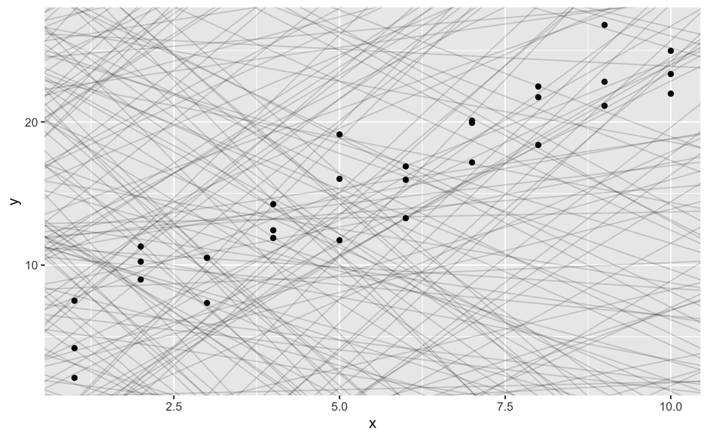

```r
models <- tibble(
  a1 = runif(250,-20,40),
  a2 = runif(250,-5,5)
)

ggplot(sim1,aes(x,y))+
  geom_point()+
  geom_abline(aes(intercept = a1, slope = a2), data = models, alpha = .15)
```

#has input a,data and it takes the position of a1, which is our y-intercept, and continually adds the slope of 1.5. Both of these are given in our a input. data is taking the x input from our actual data. the model1 produces a output based off the value of the x’s in the data.

```r
model1 <- function(a,data){
  a[1] + data$x *a[2]
  #this is just y= mx+b
}
model1(c(7,1.5), sim1)
```

```
 [1]  8.5  8.5  8.5 10.0 10.0 10.0 11.5 11.5 11.5 13.0 13.0 13.0 14.5 14.5 14.5 16.0 16.0 16.0 17.5 17.5
[21] 17.5 19.0 19.0 19.0 20.5 20.5 20.5 22.0 22.0 22.0
```

```r
#we manually created a model with parameters y-intercept is 7 and 1.5 is the slope
```

#root mean squared deviation #this takes the model above and finds the difference between the outputs of the actual data and the model, then takes the root mean squared deviation.

```r
measure_distance <- function(mod, data){
  diff<- data$y - model1(mod,data)
  sqrt(mean(diff^2))
}
measure_distance(c(7,1.5),sim1)
```

```
[1] 2.665212
```

```r
measure_distance(c(6,1),sim1)
```

```
[1] 5.448432
```

#since a1 and a2 are the models slope and intercept, we want it variable, but sim1 is the data we are modeling so we can integrate that data into the function

```r
sim1_dist <- function(a1,a2){
  measure_distance(c(a1,a2), sim1)
  #measuring the distance using the randomly generated y-intercept(a1) and slope(a2) to the data (sim1)
}
sim1_dist
```

```
function(a1,a2){
  measure_distance(c(a1,a2), sim1)
  #measuring the distance using the randomly generated y-intercept(a1) and slope(a2) to the data (sim1)
}
```

```r
models <- models %>%
  mutate(dist = purrr::map2_dbl(a1,a2, sim1_dist))
models
```

| a1 | a2 | dist |
| --- | --- | --- |
| 37.80369250 | 1.89174530 | 32.776423 |
| -9.85462086 | 1.66811388 | 16.360681 |
| 3.10481832 | -1.39634358 | 22.489625 |
| -14.59649024 | -1.12276123 | 37.464657 |
| 1.63544523 | 3.69065680 | 8.248456 |
| 27.07214606 | -0.84683317 | 11.026599 |
| 30.15972144 | -2.20236999 | 12.660275 |
| -10.21402253 | -4.13322173 | 51.648819 |
| -19.20522417 | 4.34114020 | 12.850545 |
| 35.68932954 | -0.54656497 | 18.850319 |

[output cut: 240 more lines]

```r
# create a new column called dist and we use map2 which is a lapply for tidy, where we apply the measuring the distance across all instances of a1 and a2??
```

#since we associated each model with it’s corrosponging root mean squared deviation(how well the model fits), we can select the top 10 of those models

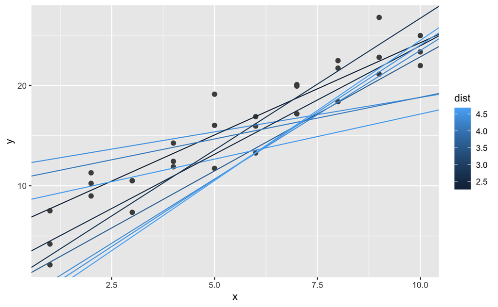

```r
ggplot(sim1, aes(x,y))+
  geom_point(size = 2, color = "grey30") +
  geom_abline(
    aes(intercept = a1, slope = a2, color = dist),
    data = filter(models, rank(dist) <= 10)
  )
```

#now we are just ploting all slope and intercepts combinationns from a1,a2.

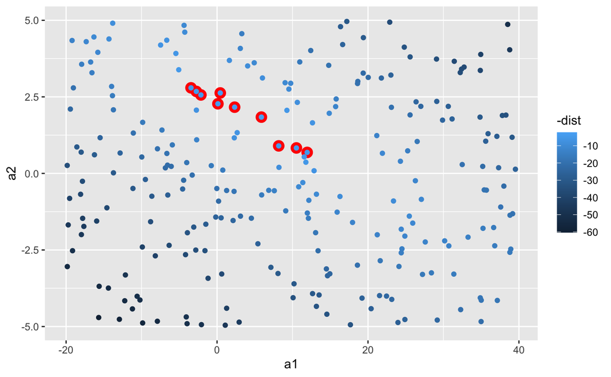

```r
ggplot(models, aes(a1,a2))+ #layer 1
  geom_point(data = filter(models,rank(dist) <= 10), size = 4, color = "red")+ #layer 2
  geom_point(aes(color = -dist))#layer3
```

#systematically creates a grid of combinitions of y-intercepts and slopes.

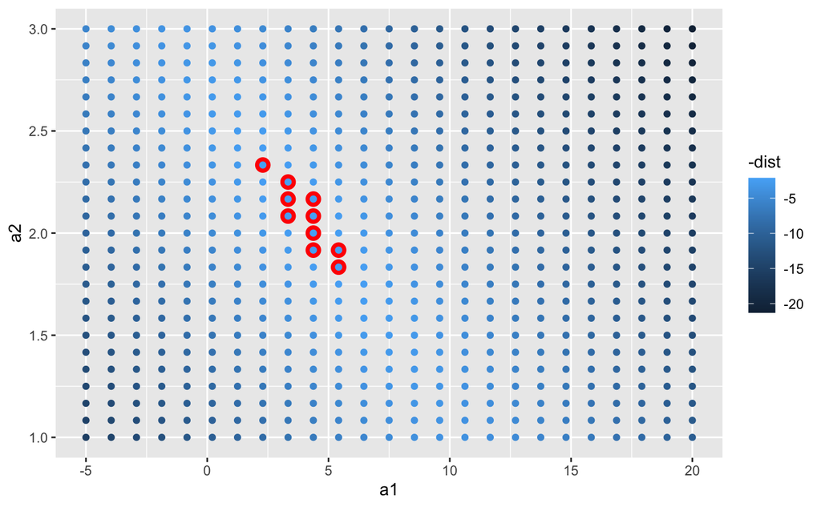

```r
grid <- expand.grid(
  a1 = seq(-5,20, length = 25),
  a2 = seq(1,3, length = 25)
) %>%
  mutate(dist = purrr::map2_dbl(a1,a2, sim1_dist))
grid %>%
  ggplot(aes(a1,a2))+
  geom_point(data = filter(grid,rank(dist) <= 10), size = 4, color = "red")+
  geom_point(aes(color = -dist))
```

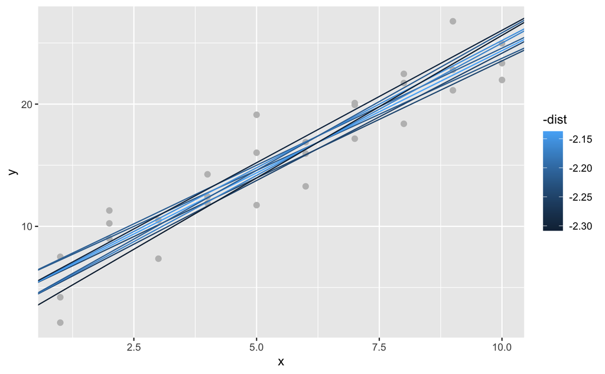

```r
ggplot(sim1, aes(x,y)) +
  geom_point(size = 2, color = "grey") +
  geom_abline(
    aes(intercept = a1, slope = a2, color = -dist),
    data = filter(grid,rank(dist) <=10)
  )
```

```r
best <- optim(c(0,0), measure_distance, data = sim1)
best
```

```
$par
[1] 4.222248 2.051204

$value
[1] 2.128181

$counts
function gradient
      77       NA

$convergence
[1] 0

$message
NULL
```

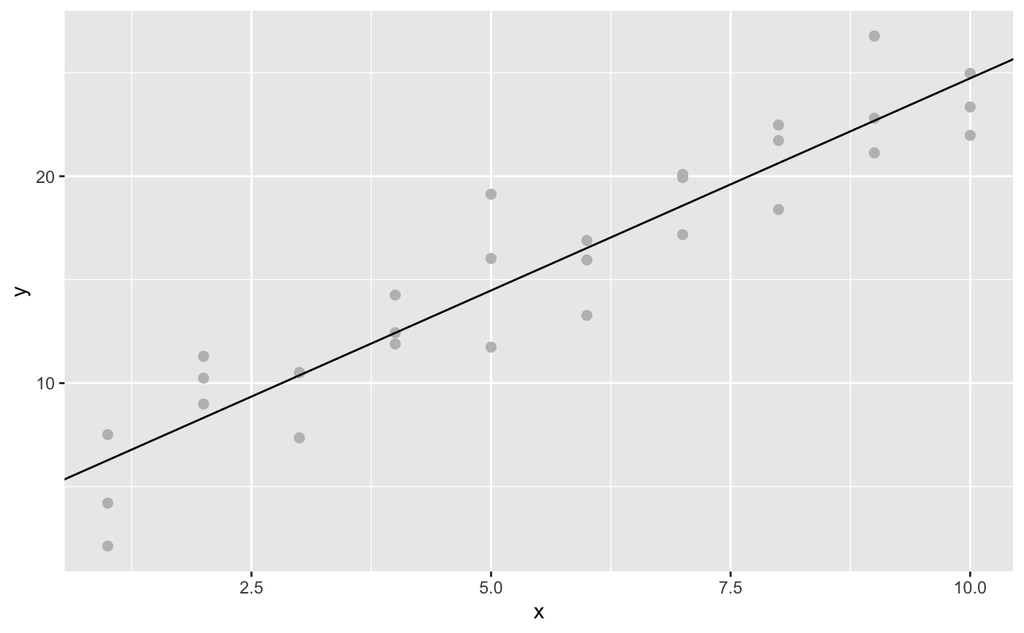

```r
ggplot(sim1, aes(x,y)) +
  geom_point(size = 2, color = "gray")+
  geom_abline(intercept = best$par[1], slope = best$par[2])
```

base R algorthems

```r
sim1_mod <- lm(y ~ x, data = sim1)
sim1_mod
```

```
Call:
lm(formula = y ~ x, data = sim1)

Coefficients:
(Intercept)            x
      4.221        2.052
```

```r
broom::tidy(sim1)
```

| column | n | mean | sd | median | trimmed | mad | min | max | range | skew | kurtosis | se |
| --- | --- | --- | --- | --- | --- | --- | --- | --- | --- | --- | --- | --- |
| x | 30 | 5.50000 | 2.921384 | 5.50000 | 5.50000 | 2.500000 | 1.000000 | 10.00000 | 9.00000 | 0.0000000 | 1.775758 | 0.5333693 |
| y | 30 | 15.50425 | 6.372218 | 15.99041 | 15.68143 | 5.308352 | 2.125473 | 26.77701 | 24.65154 | -0.1812195 | 2.162675 | 1.1634025 |

#prediction train? split

```r
library(rsample)
data_split <- initial_split(sim1)
data_train <- training(data_split)
data_test <- testing(data_split)
```

model fitting

```r
model <- lm(y ~x, data = data_train)
model
```

[output not shown]

```r
prediction <- predict(model, data_test)
prediction
```

```
       1        2        3        4        5
 7.71475 12.08341 14.26775 14.26775 16.45208
       6        7        8
18.63641 23.00507 25.18941
```

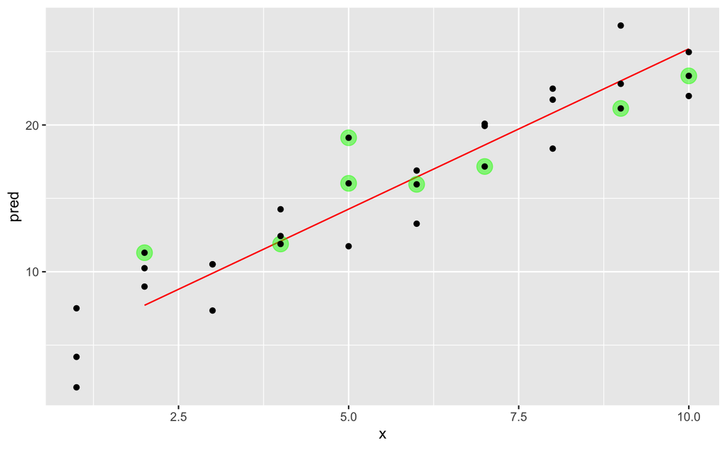

```r
data_test <- data_test %>%
  mutate(pred = predition)

ggplot(data_test)+
  geom_line(aes(x,pred), color = "red")+
  geom_point(aes(x,y), size = 5, color = "green", alpha = .5)+
  geom_point(data = sim1, aes(x,y))
```

```r
yardstick::metrics(data_test,y,pred)
```

| .metric | .estimator | .estimate |
| --- | --- | --- |
| rmse | standard | 2.4725239 |
| rsq | standard | 0.8286725 |
| mae | standard | 2.0090893 |